# 1 記述統計学

## 1.3 tidyデータについて

### 1.3.1 tidyデータとは

`tidy`データ(2014～)という概念があります。これはデータ分析言語として`Python`言語と双璧をなす`R`言語において提唱された概念です。提唱者は`R`言語の神様として有名な **Hadley Wickham**です。`tidy`データとは、簡単に言えばすべての変数情報を列として持つデータのことをいいます。

データがこの形式に整理されている利点は、特にデータ分析、機械学習を実行する際のコストのうち**前処理**と呼ばれるデータ成型のためのコストの面で非常に大きくなります。Wickhamは`tidy`データの概念を中心としたエコシステムを作り上げようとしています。

[figure not shown]

少し抽象的なので、例を見て考えてみよう。まず`tidy`でないデータから見てみることにしよう。

```python
a0 = np.array(['A', 'B', 'C', 'D', 'E'])
a1 = np.array([150,160,175,130,155])
a2 = np.array([100,130,150,90,130])

bp_df = pd.DataFrame({
    '患者':a0,
    '投薬前血圧':a1,
    '投薬後血圧':a2,
})

bp_df
```

|  | 患者 | 投薬前血圧 | 投薬後血圧 |
| --- | --- | --- | --- |
| 0 | A | 150 | 100 |
| 1 | B | 160 | 130 |
| 2 | C | 175 | 150 |
| 3 | D | 130 | 90 |
| 4 | E | 155 | 130 |

さてこれを`tidy`データ化してみるとどうなるだろうか。

```python
a3 = np.array(['A', 'B', 'C', 'D', 'E','A', 'B', 'C', 'D', 'E'])
a4 = np.array([150,160,175,130,155,100,130,150,90,130])
a5 = np.array(['前', '後'])
a6 = np.repeat(a5, [5,5], axis=0)

tidybp_df = pd.DataFrame({
    '患者':a3,
    '血圧':a4,
    '状態':a6
})
print(tidybp_df)
```

```
  患者   血圧 状態
0  A  150  前
1  B  160  前
2  C  175  前
3  D  130  前
4  E  155  前
5  A  100  後
6  B  130  後
7  C  150  後
8  D   90  後
9  E  130  後
```

`tidy`データの意味が伝わったでしょうか。

**tidyの条件**

**・一つの変数に一つの列**

**・一つの観測に一つの行**

**・一つの表には一種類の観測**

**・一つのセルには1つの値**

`Python`や`R`では近年、このデータ形式に対してさまざな関数が対応するように設計されています。普段のデータ作成においても、`tidy`データを念頭において作成しておくとよいでしょう。

[問題] 以下の`tidy`でないデータを`tidy`データに直してみてください。

```python
weather_notidy = pd.read_csv('./data/weather_notidy.csv', encoding='cp932')
weather_notidy
```

|  | 地点 | 6時 | 12時 | 18時 |
| --- | --- | --- | --- | --- |
| 0 | 札幌 | 晴れ | 晴れ | 晴れ |
| 1 | 東京 | 曇り | 雨 | 雨 |
| 2 | 神戸 | 雨 | 曇り | 晴れ |

[解答]

```python
b1 = np.repeat(['札幌', '東京', '神戸'], 3)
b2 = np.array(['6時', '12時', '18時']*3)
b3 = np.array(['晴れ','晴れ','晴れ','曇り','雨','雨','雨','曇り','晴れ' ])

tidyweather_df = pd.DataFrame({
    '地点':b1,
    '時刻':b2,
    '天候':b3
})
print(tidyweather_df)
```

```
   地点   時刻  天候
0  札幌   6時  晴れ
1  札幌  12時  晴れ
2  札幌  18時  晴れ
3  東京   6時  曇り
4  東京  12時   雨
5  東京  18時   雨
6  神戸   6時   雨
7  神戸  12時  曇り
8  神戸  18時  晴れ
```

## 1.4 データの可視化

ここではPythonを使って、**データの可視化**(data visualization)をする方法について学んでいきます。`matplotlib`や`seaborn`というライブラリが標準的に使われています。

### 1.4.1 1変量データの可視化

```python
#ライブラリなどの準備
import numpy as np
import pandas as pd
#表示桁数を調節する
%precision 3
import matplotlib.pyplot as plt
import japanize_matplotlib    # 日本語のトーフ化を避けるため
import seaborn as sns
```

```
[ 0.514  0.1   -1.308  0.351  0.962  1.308  0.826 -1.078  2.283 -0.627]
[-1.061 -0.161 -0.265 -0.118 -1.564  1.077  0.098  1.589 -0.15  -0.422]
```

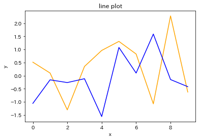

```python
#折れ線グラフ
#正規分布に従う10個の乱数x,yの生成
from numpy.random import randn
x = randn(10)
y = randn(10)
print(x)
print(y)

#線グラフの描画
plt.plot(x, color = "orange")
plt.xlabel("x")
plt.plot(y, color = "blue")
plt.ylabel("y")
plt.title("line plot")
plt.show()
```

統計学的に大変重要なグラフである**ヒストグラム**(histogram)は以下のように作成できます。

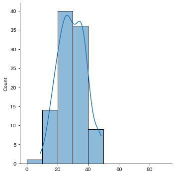

```python
#正規乱数を100個生成
from numpy.random import normal
x = normal(loc=30,scale=10,size=100)

#seabornでヒストグラム作成(kdeはカーネル密度推定)
sns.displot(x,bins=range(0,100,10), kde=True)
plt.show()
```

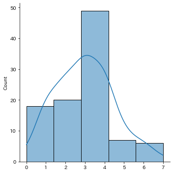

```python
#二項乱数を100個生成
from numpy.random import binomial
x = binomial(p = 0.3, n = 10,size=100)

#seabornでヒストグラム作成
sns.displot(x,bins = 5, kde = True)
plt.show()
```

**度数＝その値が何個出てきているか**

**ヒストグラム＝度数を縦軸、横軸に観測された値のグラフ**

[問題] ヒストグラムをみるときに注目したいポイントについて考えてみましょう。

[解答]

ヒストグラムを見るときには、

**1) 峰の数=山の頂点の個数（母集団の確率分布の種類を決める情報）**  
**2) 全体の形状（=なだらかか、急か、どのくらい広がっているか→分散）**  
**3) 変域（どこからどこまで数字が出ているか）, 幅（そのヒストグラムがどう作られたか）**

について注目すると良いです。

### 1.4.2 多変量データの可視化

次に多変量データの可視化、特に2変量の場合について考えよう。そのパターンとしては、

**1) 量的変数×量的変数 → 散布図**

**2) 量的変数×質的変数 → 箱ひげ図, バイオリンプロット**

**3) 質的変数×質的変数 → クロス集計表**

があります。

#### 1.4.2.1 散布図

まずは、量×量の場合の**散布図**(scatter plot)を書いてみましょう。 ちなみに、以下に使用する`iris`データセットは非常に有名なデータセットであり、統計学では機械学習では頻繁に登場するので、どんなデータセットなのか覚えてしまうとよいでしょう。(ちなみに大統計学者Fisherのアヤメの分類のデータセットであり、歴史的な意義もあります。)

```python
#irisデータのダウンロードと確認
iris = sns.load_dataset('iris')
iris.head(n = 5)
```

|  | sepal_length | sepal_width | petal_length | petal_width | species |
| --- | --- | --- | --- | --- | --- |
| 0 | 5.1 | 3.5 | 1.4 | 0.2 | setosa |
| 1 | 4.9 | 3.0 | 1.4 | 0.2 | setosa |
| 2 | 4.7 | 3.2 | 1.3 | 0.2 | setosa |
| 3 | 4.6 | 3.1 | 1.5 | 0.2 | setosa |
| 4 | 5.0 | 3.6 | 1.4 | 0.2 | setosa |

[問題] `species`ごとに、各変数の平均値を求め、散布図をかいてみてください。

[解答]

```python
iris.groupby("species").mean()
```

| species | sepal_length | sepal_width | petal_length | petal_width |
| --- | --- | --- | --- | --- |
| setosa | 5.006 | 3.428 | 1.462 | 0.246 |
| versicolor | 5.936 | 2.770 | 4.260 | 1.326 |
| virginica | 6.588 | 2.974 | 5.552 | 2.026 |

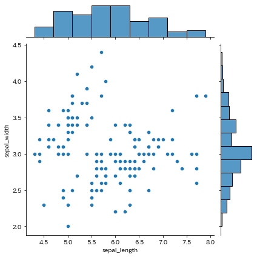

```python
#散布図の作成(joint plot)
sns.jointplot(x = iris.sepal_length,
              y = iris.sepal_width,
              data = iris)
plt.show()
```

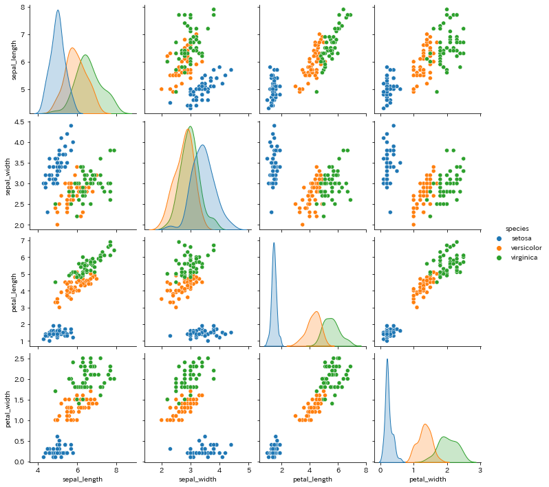

```python
sns.pairplot(iris, hue = "species")
plt.show()
```

#### 1.4.2.2 箱ひげ図

量的変数×質的変数の可視化に便利なのが、**箱ひげ図**(boxplot)です。これは以下のようにかきます。

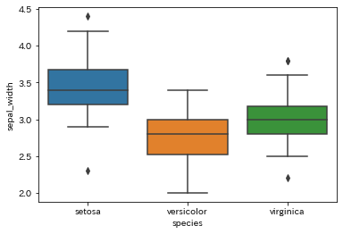

```python
sns.boxplot(x = "species", y = "sepal_width", data = iris)
plt.show()
```

#### 1.4.2.3 バイオリンプロット

最近、箱ひげ図の代わりに**バイオリンプロット**と呼ばれるものもよく使われるようになってきました。これにより、箱ひげ図とカーネル密度推定を同時に描画した図を得ることができます。

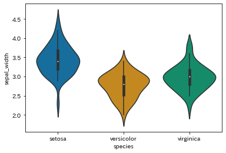

```python
sns.violinplot(x = "species", y = "sepal_width",
               data = iris, palette = "colorblind")
plt.show()
```

#### 1.4.2.4 クロス集計表

質的変数同士の関係を表すには、**クロス集計表**(cross table)にまとめるのが一般的です。ここでは、`tidy`データからクロス集計表を作成してみましょう。

```python
tidyweather_df
```

|  | 地点 | 時刻 | 天候 |
| --- | --- | --- | --- |
| 0 | 札幌 | 6時 | 晴れ |
| 1 | 札幌 | 12時 | 晴れ |
| 2 | 札幌 | 18時 | 晴れ |
| 3 | 東京 | 6時 | 曇り |
| 4 | 東京 | 12時 | 雨 |
| 5 | 東京 | 18時 | 雨 |
| 6 | 神戸 | 6時 | 雨 |
| 7 | 神戸 | 12時 | 曇り |
| 8 | 神戸 | 18時 | 晴れ |

```python
#tidyweather_dfを使ってクロス集計
cross = pd.pivot_table(data=tidyweather_df,
                       index='地点',
                       columns='天候',
                       aggfunc='count'
                      )
cross
```

| 天候 地点 | 時刻 晴れ | 時刻 曇り | 時刻 雨 |
| --- | --- | --- | --- |
| 札幌 | 3.0 | NaN | NaN |
| 東京 | NaN | 1.0 | 2.0 |
| 神戸 | 1.0 | 1.0 | 1.0 |

## 1.5 相関係数

2つの変数間になんらかの関係があるとき**相関**(correlation)があるといいます。相関という言葉は厳密には、2つの量的変数の線形な関係についてあてられるべき言葉ですが、ここではより広義に相関の意味をとっておきます。

この場合も、可視化のときと同じく大分類として3通りになります。

**1) 量的変数×量的変数 → ピアソンの積率相関係数**

**2) 量的変数×質的変数 → 相関比**

**3) 質的変数×質的変数 → クラメールの連関係数**

### 1.5.1 相関係数(ピアソンの積率相関係数)

まずは、量×量のときの**ピアソンの積率相関係数**(Pearson's correlation coefficient)についてここで見ておきましょう。この値は単に**相関係数**(correlation coefficient)とよぶことが多いです。

$$Cor(x, y) = \frac{Cov(x, y)}{sd(x)\cdot sd(y)} = \frac{\frac{1}{n}\sum_{i=1}^{n}(x_i - \bar{x})(y - \bar{y})}{\sqrt{\frac{1}{n}\sum_{i=1}^{n}(x - \bar{x})^2}\sqrt{\frac{1}{n}\sum_{i=1}^{n}(y - \bar{y})^2}}$$

[問題] 上の式で定義された相関係数の分子の値を**共分散**(covariance)というが、この値が相関の強さを決定することを説明してください。

```python
weather_d.drop("日", axis = 1).corr()
```

|  | 平均気温 | 平均湿度 | 日照時間 |
| --- | --- | --- | --- |
| 平均気温 | 1.000000 | 0.227116 | 0.066385 |
| 平均湿度 | 0.227116 | 1.000000 | -0.672524 |
| 日照時間 | 0.066385 | -0.672524 | 1.000000 |

### 1.5.2 相関比

質的変数と量的変数の関係の深さを表すには、**相関比**(correlation ratio)を用います。この値は、以下のように定義されます。

$$ \eta^2 = \frac{S_B}{S_W + S_B}$$

ここで、$S_B$は級間変動、$S_W$は級内変動と呼ばれる値です。以下のデータを用いて計算法を確認してみよう。

```python
x = np.array([400,500,600, 400,450,350, 500,600,700])
y = np.repeat(['Kobe','Kagoshima','Osaka'], 3)

salary_df = pd.DataFrame({
    'salary' : x,
    'place' : y
})

salary_df
```

|  | salary | place |
| --- | --- | --- |
| 0 | 400 | Kobe |
| 1 | 500 | Kobe |
| 2 | 600 | Kobe |
| 3 | 400 | Kagoshima |
| 4 | 450 | Kagoshima |
| 5 | 350 | Kagoshima |
| 6 | 500 | Osaka |
| 7 | 600 | Osaka |
| 8 | 700 | Osaka |

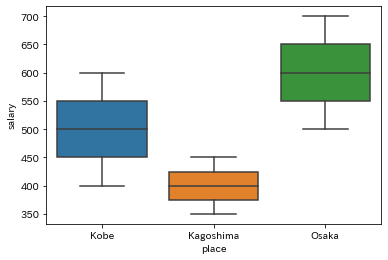

```python
sns.boxplot(x = "place", y = "salary", data = salary_df)
plt.show()
```

```python
#全体平均の計算
mu = salary_df.salary.mean()
print('全体平均', mu)

level_mu = np.repeat([500, 400, 600],3)
print('水準平均', level_mu)

#級間変動
S_B = np.sum((level_mu - mu)**2)
print('級間変動', S_B)

#級内変動
residuals = salary_df.salary - level_mu
print('残差', residuals)
S_W = np.sum(residuals**2)
print('級内変動', S_W)

#相関比
eta2 = (S_B)/(S_B + S_W)
print('相関比', eta2)
```

```
全体平均 500.0
水準平均 [500 500 500 400 400 400 600 600 600]
級間変動 60000.0
残差 0   -100
1      0
2    100
3      0
4     50
5    -50
6   -100
7      0
8    100
Name: salary, dtype: int64
級内変動 45000
相関比 0.5714285714285714
```

ちなみに、相関比の分母の$S_B + S_W$のことを**全体変動**$S_T$といいこの値は**偏差平方和**と一致します。すなわち

$$偏差平方和 = 級間変動 + 級内変動$$

が成立しています。これを**平方和分解**(decomposition of sum of squares)といい、統計学的にたいへん重要な概念です。

[問題] 上記のことが本当に成り立っているか確認してください。

[解答] 以下を実行して偏差平方和を計算してみると、確かに級間変動と級内変動の和になっていることがわかります。

```python
#偏差平方和の計算
np.sum((salary_df.salary - mu)**2)
```

```
105000.0
```

数学的に証明できる人は証明してみるのも面白いでしょう。幾何学的には三平方の定理として説明できたりもします。

### 1.5.3 クラメールの連関係数

質的変数同士の場合は、クロス集計表に対して、**クラメールの連関係数**(Cramer's coefficient of association)$r_c$を計算することで、2つの質的変数の結びつきの強さを測定します。この値は以下の式で与えられます。

$$r_c = \sqrt{\frac{\chi^2}{n(k-1)}}$$

ここで、$\chi^2$を**カイ二乗値**(chi-square)と呼び。以下の式で定義します。

$$\chi^2 = \sum \frac{(観測度数 - 期待度数)^2}{期待度数}$$

そのほか$n$は全データ数、$k$はクロス表の次元のうち小さい方の値です。以下のデータを用いて実際に計算してみよう。

| 科目\専攻 | 数学専攻 | それ以外 | 周辺度数 |
| --- | --- | --- | --- |
| 算数好き | 30 | 20 | 50 |
| 国語好き | 10 | 60 | 70 |
| 周辺度数 | 40 | 80 | 120 |

```python
#実測度数表
sample_cross = np.array([[30,20],
                         [10,60]])

#期待度数表の作成
ex_cross = np.array([[40 * 50/120, 80*50/120],
                    [40 * 70/120, 80*70/120]])
print(ex_cross)
```

```
[[16.667 33.333]
 [23.333 46.667]]
```

[問題] 上記の計算をして求める期待度数とは何か答えてください。

[解答] 2つの質的変数に関係が全くなかった時に期待される度数のこと。

```python
#クラメール連関係数計算の続き
chi_table = (sample_cross - ex_cross)**2/ex_cross
print(chi_table)

chisq = np.sum(chi_table)
print('カイ二乗値', chisq)

r_c = np.sqrt(chisq/(np.sum(sample_cross)*(min(sample_cross.shape)-1)))
print('クラメールの連関係数', r_c)
```

```
[[10.667  5.333]
 [ 7.619  3.81 ]]
カイ二乗値 27.428571428571427
クラメールの連関係数 0.47809144373375745
```

連関係数は0から１の値をとります。1に近いほど関係が強い、0に近いほど関係が弱いことを表します。